# Internet of Things

Gowrishankar Anand Sudhan

11 December 2015

# Phase I : Exploratory Data Analysis(EDA)

## Putting the data in the correct form

```r
#Eliminate the first var(indexing Var is not useful for us and memory consuming)
SmallLogs <- SmallLogs[,-1]

# Setting date as POSIXct object that we can do compuations over it
SmallLogs$time <- as.POSIXct(SmallLogs$date,format="%Y-%m-%d %H:%M:%S")

#Extract scene names from the variable "scene" and convert them as factors
test=sub(".*=", "", SmallLogs$scene)
SmallLogs$scene_name<- substr(test,1, nchar(test)-1)
SmallLogs$scene_name<-as.factor(SmallLogs$scene_name)
```

## Calculating time interaction by station

```r
library(dplyr)
test=SmallLogs %>% group_by(station,visitor) %>% summarise(first=first(time)) #first login into the station
test2=SmallLogs %>% group_by(station,visitor) %>% summarise(last=last(time)) #last logout from the station
dataset=merge(test,test2,by=c("station","visitor"))
#Time of interaction
dataset$time_inter=as.numeric(dataset$last-dataset$first)
```

### Distribtion of time of interaction in seconds

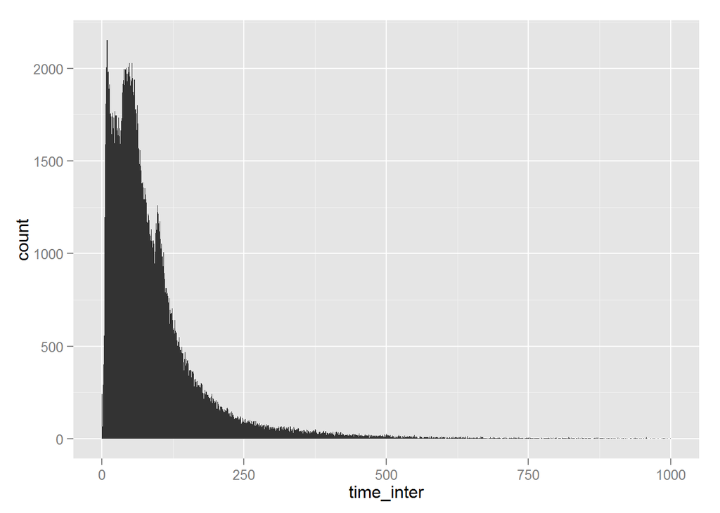

```r
library(ggplot2)
ggplot(data=dataset,aes(x=time_inter))+geom_bar(binwidth=1)+xlim(0,1000)
```

The time of interaction have the great concentration before 500s(8 min) and most of interactions lasts two min if outliers are eliminated. Only 515 visitors have a time of interaction greater than 500s and the data miglt also have some errors like having only login data and no logout data.

```r
#Agreggate stations for better visualisations
index_0=grep("cnk0",as.character(dataset$station))
index_1=grep("cnk1",as.character(dataset$station))
index_2=grep("cnk2",as.character(dataset$station))
index_3=grep("cnk3",as.character(dataset$station))
index_4=grep("cnk4",as.character(dataset$station))
index_5=grep("cnk5",as.character(dataset$station))
index_6=grep("cnk6",as.character(dataset$station))
index_7=grep("cnk7",as.character(dataset$station))

C=c(rep("cnk0",length(index_0)),rep("cnk1",length(index_1)),rep("cnk2",length(index_2)),rep("cnk3",length(index_3)),rep("cnk4",length(index_4)),rep("cnk5",length(index_5)),rep("cnk6",length(index_6)),rep("cnk7",length(index_7)))

dataset$stationAgg=C
```

### Distribution of time interaction by station

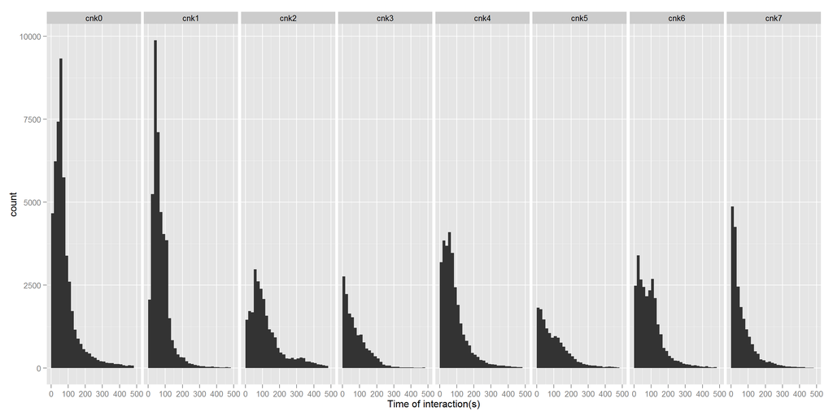

```r
ggplot(data=dataset,aes(time_inter))+geom_bar()+facet_grid(~stationAgg)+xlim(0,500)+xlab("Time of interaction(s)")
```

All the distributions of time interaction of stations tend to have the same shape So there is a similarity between visitor in the time they spend over machines. Although, we have a great count in the aggegated stations chnk0 and chnk1 for a time of interaction about 60s(1min).

## Relation between time of interaction, weekday and hour of the day

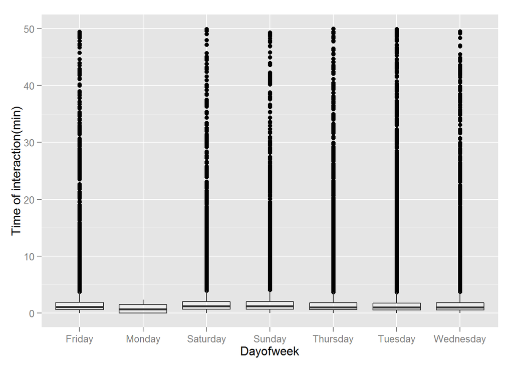

```r
dataset$Dayofweek=as.factor(weekdays(dataset$first))
ggplot(dataset,aes(x=Dayofweek,y=time_inter/60))+geom_boxplot(alpha=1/3)+ylim(0,50)+ylab("Time of interaction(min)")
```

In the over all shape of distributions according to the time of interaction, we remark that days don’t have a real influence on the time of interaction, unless the special case of Monday. We remark also a great concentration of interaction whose time is less than *5min*. Monday figure on the plot with a small amount of interaction because machines aren’t used heavily that day of the week.  
we can look at the table of count of days that visitors use the machines

```r
table(dataset$Dayofweek)
```

```
##
##    Friday    Monday  Saturday    Sunday  Thursday   Tuesday Wednesday
##     38142        51     40992     37606     33388     43561     31730
```

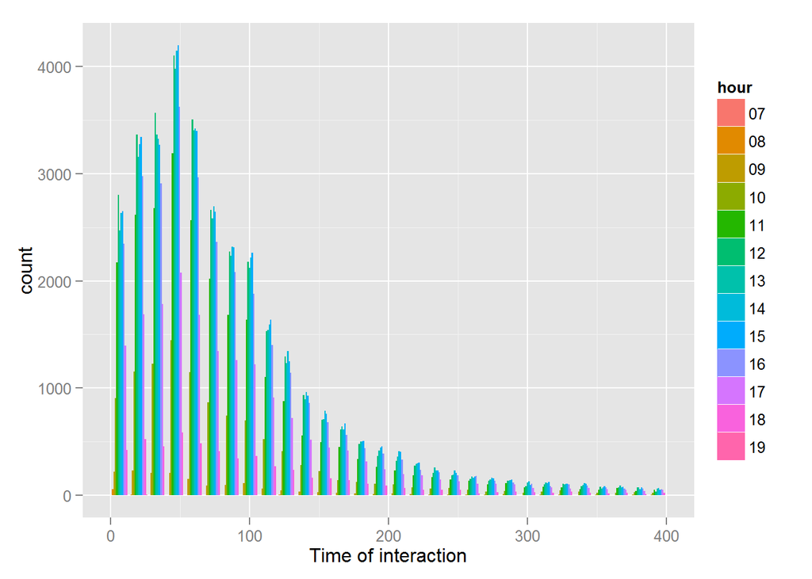

```r
#hours of the day
dataset$hour<- format(dataset$first,"%H")
ggplot(data = dataset,aes(x=time_inter,fill=hour))+geom_bar(position = "dodge")+xlim(0,400)+xlab("Time of interaction")
```

Hour of logging does have influence on time interaction with stations, The hours 12, 13, 14 and 15 are the part of the day that visitors interact with stations the most.

**What features are used the most?**  
The next table will show the most used actions by visitors

```r
head(sort(table(SmallLogs$scene_name),decreasing = TRUE),50)
```

```
##
##                    Splash                      Main
##                    555710                    213728
##                   Example                     Dance
##                    170371                    167087
##       removalWarningScene                      Info
##                    137027                     85020
##             ComicStripPre                  Feedback
##                     77948                     73986
##                      Menu                      Idle
##                     70660                     60783
##                    Screen               Instruction
##                     58143                     47472
##            ComicStripNext                   Results
##                     46544                     45510
##              GamePreState             GameNextState
##                     40205                     39858
##                    Result                     Watch
##                     35638                     35600
##                 TakeAPill                   Screen1
##                     28570                     28294
##                   MapPage                 ChooseOne
##                     27746                     26214
##                OneCorrect                S03ResultA
##                     23291                     22820
##                    Levels                Evaluation
##                     21806                     21194
## CustomRemovalWarningScene                  MainMenu
##                     21146                     21134
##                  LevelTwo                    Listen
##                     19220                     18799
##                     Intro                   Torture
##                     17770                     17732
##                  S02GameB                  S02GameA
##                     17295                     17116
##                  Overview                  LevelOne
##                     17083                     16968
##               Explanation                  OneWrong
##                     16704                     16150
##                    splash                  YourTurn
##                     15759                     15494
##                 Questions                      Chat
##                     15074                     14687
##                Background                   Regions
##                     14552                     13800
##                S03ResultB            QuestionScreen
##                     13551                     13154
##            MorphingImgPre                 ShotPhoto
##                     13050                     12816
##                     Video                 S01StartB
##                     12647                     12195
```

```r
tb=(table(SmallLogs$scene_name))


tb=data.frame(tb)
sb=subset(tb,Freq>9000)
```

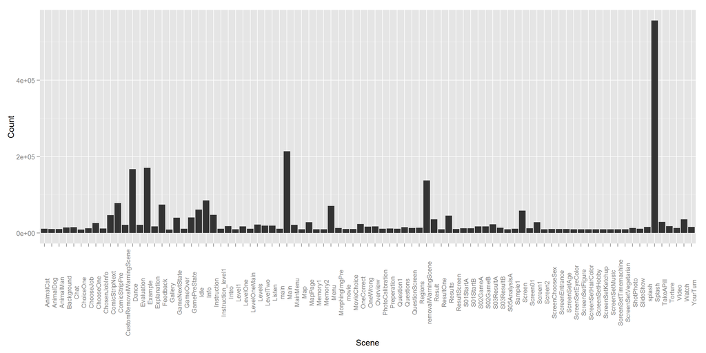

```r
#This vizualisation is about the most 129 featured used
ggplot(data = sb,aes(x=Var1,y=Freq))+geom_bar(stat="identity")+theme(axis.text.x=element_text(angle=90,size=9))+xlab("Scene")+ylab("Count")
```

The actions (scenes or features): Splash, Main, Example and dance are the most used by user when they interact with machines.

We can conclude from this analysis that by constructing time of interaction, visitors are quite similar and belong to one big cluster. To compute a very different distance we shall use k-means algorithm over moralities of variables like hour, Week of the day, Station..